# Genus, diabetes data set

### RDA vs CLR

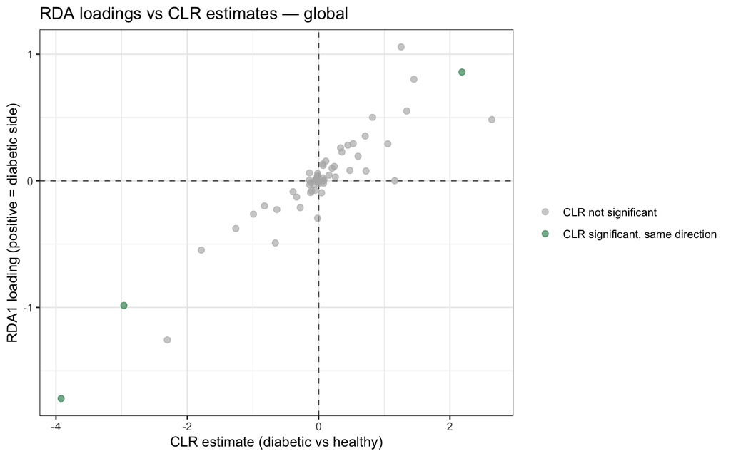

```r
# Sign of RDA1 is arbitrary; orient so that the diabetic group has positive RDA1
rda1_scores_china <- scores(rda_china_out$rda, display = "sites")[, "RDA1"]
rda1_sign_china <- ifelse(
  mean(rda1_scores_china[rda_china_out$meta$Disease.MESH.ID == "D003924"], na.rm = TRUE) >=
  mean(rda1_scores_china[rda_china_out$meta$Disease.MESH.ID == "D006262"], na.rm = TRUE),
  1, -1
)

comp_china <- compare_rda_clr(
  rda_obj  = rda_china_out$rda,
  clr_res  = clr_china,
  tax_df   = as(tax_table(global_t$clr), "matrix") %>% as.data.frame(),
  rda1_sign = rda1_sign_china
)

plot_rda_clr_comparison(
  comp_china,
  x_label = "CLR estimate (diabetic vs healthy)",
  y_label = "RDA1 loading (positive = diabetic side)",
  title   = "RDA loadings vs CLR estimates — global"
)
```

```r
comp_china %>%
  arrange(desc(abs(rda1_loading))) %>%
  select(Genus.x, rda1_loading, clr_estimate, clr_q, direction_agreement) %>%
  head(5)
```

```
## # A tibble: 5 × 5
##   Genus.x                  rda1_loading clr_estimate   clr_q direction_agreement
##   <chr>                           <dbl>        <dbl>   <dbl> <lgl>
## 1 g__Roseburia                   -1.72         -3.92 0.00551 TRUE
## 2 g__Bacteroidales_unclas…       -1.26         -2.30 0.107   TRUE
## 3 g__Bifidobacterium              1.06          1.26 0.517   TRUE
## 4 g__Faecalibacterium            -0.985        -2.97 0.0200  TRUE
## 5 g__Megasphaera                  0.859         2.18 0.0200  TRUE
```

# Analysis 3: East vs. West — Geographical Differences in Diabetics

**Question:** Among diabetic individuals only, is there a geographical difference in gut microbiome composition between Western and Chinese (Eastern) populations?

## Visualisation

### Barplot (relative abundance, n = 50 sample)

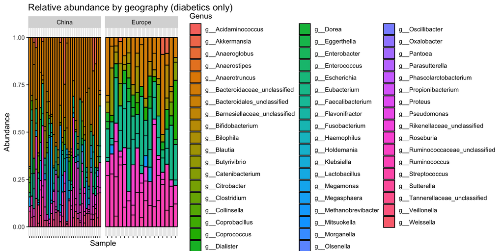

```r
ps_genus_we  <- tax_glom(we_t$rel, taxrank = "Genus")
we_genus_sampled <- sample_ps(ps_genus_we, size = min(50, nsamples(ps_genus_we)))

plot_bar(we_genus_sampled, fill = "Genus") +
  facet_nested(~ Country, scales = "free_x") +
  labs(title = "Relative abundance by geography (diabetics only)") +
  theme(axis.text.x = element_blank())
```

## Alpha Diversity

```r
alpha_we <- make_alpha_df(ps_we, we_t$pa)
```

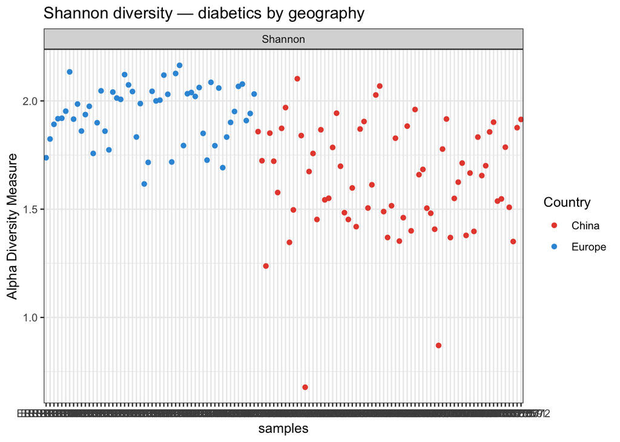

```r
plot_richness(ps_we, measures = "Shannon", color = "Country") +
  scale_color_manual(values = c("China" = "#E74C3C", "Europe" = "#3498DB")) +
  labs(title = "Shannon diversity — diabetics by geography") +
  theme_bw()
```

```r
run_kruskal(alpha_we, "Shannon", "Country")
```

```
##                            Variable Chi_squared df      P_value
## Kruskal-Wallis chi-squared  Country    47.77834  1 4.772366e-12
```

```r
run_pairwise_wilcoxon(alpha_we, "Shannon", "Country")
```

```
## # A tibble: 1 × 5
##   Variable Comparison      P_value_adj Group1 Group2
##   <chr>    <chr>                 <dbl> <chr>  <chr>
## 1 Country  Europe vs China    4.86e-12 Europe China
```

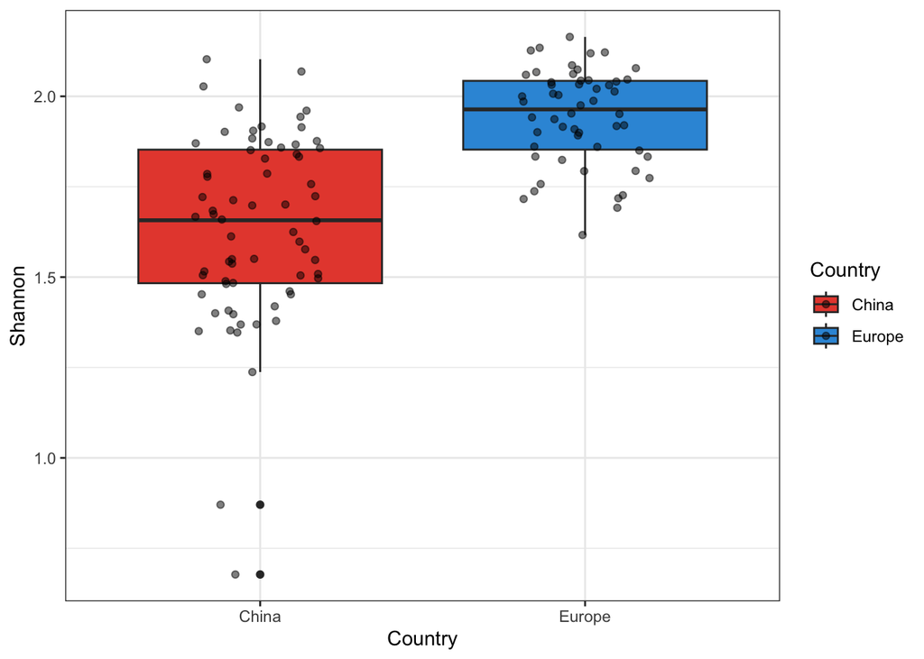

```r
ggplot(alpha_we, aes(x = Country, y = Shannon, fill = Country)) +
  geom_boxplot() +
  geom_jitter(width = 0.2, alpha = 0.5) +
  theme_bw() +
  scale_fill_manual(values = c("#E74C3C", "#3498DB"))
```

### Sequencing depth vs. Shannon

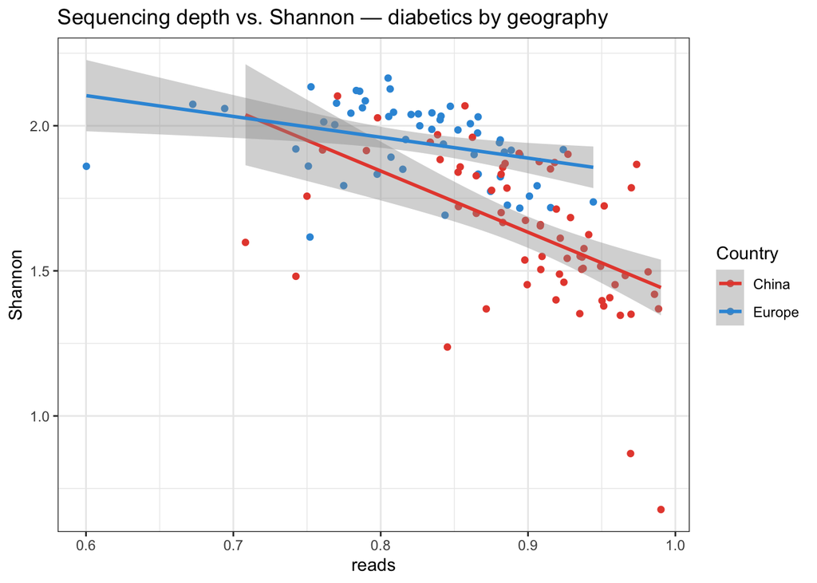

```r
alpha_we$reads <- sample_sums(ps_we)[alpha_we$sample_id]

ggplot(alpha_we, aes(x = reads, y = Shannon, color = Country)) +
  geom_point() + geom_smooth(method = "lm") +
  scale_color_manual(values = c("China" = "#E74C3C", "Europe" = "#3498DB")) +
  labs(title = "Sequencing depth vs. Shannon — diabetics by geography") +
  theme_bw()
```

```r
cor.test(alpha_we$reads, alpha_we$Shannon, method = "spearman")
```

```
##
##  Spearman's rank correlation rho
##
## data:  alpha_we$reads and alpha_we$Shannon
## S = 511978, p-value < 2.2e-16
## alternative hypothesis: true rho is not equal to 0
## sample estimates:
##        rho
## -0.6918125
```

## Beta Diversity — PERMANOVA

### Calculating the Bray-Curtis distances and the Jaccard distances

```r
bray_dist <- distance(
  ps_we,
  method = "bray"
)

jaccard_dist <- distance(
  we_t$pa,
  method = "jaccard"
)
```

### PCoA — Bray-Curtis

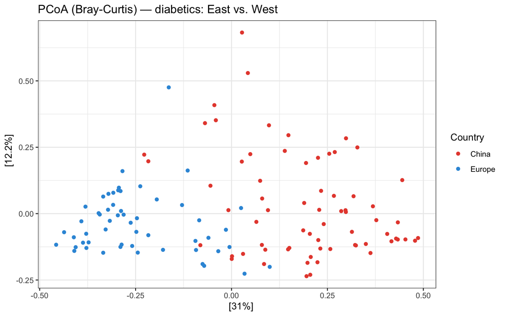

```r
bray_we <- distance(we_t$rel, method = "bray")
ord_we  <- ordinate(we_t$rel, method = "PCoA", distance = bray_we)

plot_ordination(we_t$rel, ord_we, type = "samples", color = "Country") +
  scale_color_manual(values = c("China" = "#E74C3C", "Europe" = "#3498DB")) +
  labs(title = "PCoA (Bray-Curtis) — diabetics: East vs. West") +
  theme_bw()
```

### NMDS based on Bray-Curtis distance

NMDS is another commonly used ordination method in ecology and microbiome analysis. Unlike PCoA, it focuses on preserving the rank order of distances rather than the distances themselves.

```r
we_nmds <- ordinate(
  we_t$rel,
  method = "NMDS",
  distance = "bray"
)
```

```
## *** Best solution was not repeated -- monoMDS stopping criteria:
##     18: stress ratio > sratmax
##      2: scale factor of the gradient < sfgrmin
```

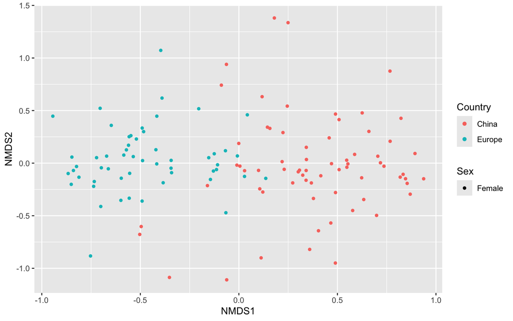

```r
plot_ordination(
  we_t$rel,
  we_nmds,
  type = "samples",
  color = "Country",
  shape = "Sex"
)
```

### PERMANOVA + Dispersion

```r
sample_df_we <- sample_data(we_t$rel) %>% data.frame()

adonis2(bray_we ~ Country,
        data = sample_df_we, permutations = 999)
```

```
## Permutation test for adonis under reduced model
## Permutation: free
## Number of permutations: 999
##
## adonis2(formula = bray_we ~ Country, data = sample_df_we, permutations = 999)
##           Df SumOfSqs      R2      F Pr(>F)
## Model      1   5.9505 0.21469 32.806  0.001 ***
## Residual 120  21.7660 0.78531
## Total    121  27.7166 1.00000
## ---
## Signif. codes:  0 '***' 0.001 '**' 0.01 '*' 0.05 '.' 0.1 ' ' 1
```

```r
disp_we <- betadisper(bray_we, sample_df_we$Country)
anova(disp_we)
```

```
## Analysis of Variance Table
##
## Response: Distances
##            Df  Sum Sq  Mean Sq F value  Pr(>F)
## Groups      1 0.06421 0.064210  4.6139 0.03372 *
## Residuals 120 1.67000 0.013917
## ---
## Signif. codes:  0 '***' 0.001 '**' 0.01 '*' 0.05 '.' 0.1 ' ' 1
```

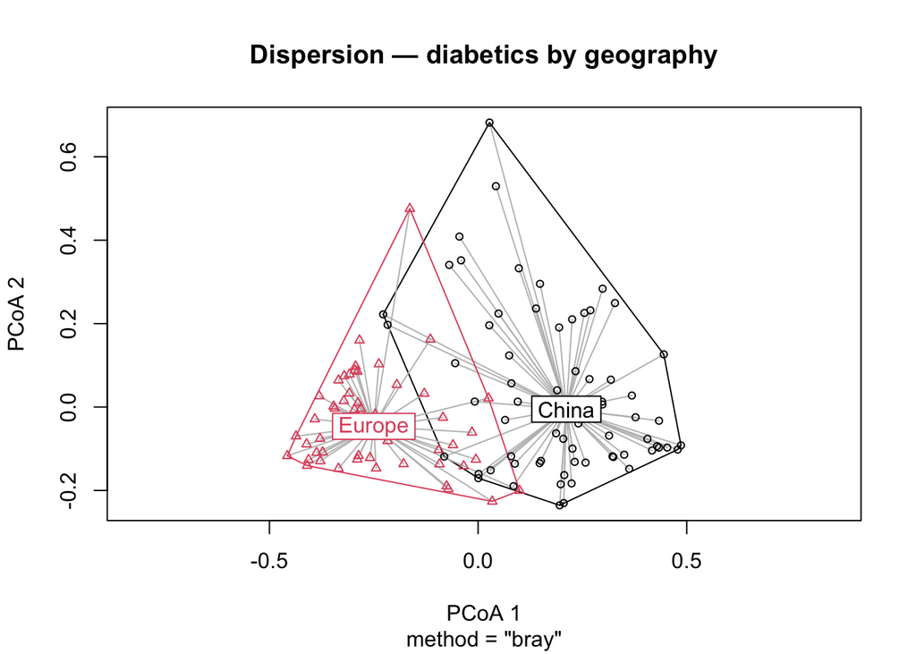

```r
plot(disp_we, main = "Dispersion — diabetics by geography")
```

## Wilcoxon Rank-Sum Test

One Wilcoxon test per taxon on relative abundances, Europe vs. China within diabetics. `log2_fc` is positive for Europe-enriched taxa.

```r
wilcox_we <- run_wilcoxon(
  ps_rel    = we_t$rel,
  group_var = "Country",
  pos_level = "Europe",   # Europe = numerator
  neg_level = "China"     # China  = denominator
)

# Top Europe-enriched (positive log2FC)
wilcox_we %>%
  filter(q_value < 0.05) %>%
  arrange(-log2_fc) %>%
  select(Genus, mean_pos, mean_neg, log2_fc, p_value, q_value) %>%
  head(10)
```

```
## # A tibble: 10 × 6
##    Genus                           mean_pos mean_neg log2_fc  p_value  q_value
##    <chr>                              <dbl>    <dbl>   <dbl>    <dbl>    <dbl>
##  1 g__Methanobrevibacter             0.0112 0         13.5   1.10e- 2 3.15e- 2
##  2 g__Dorea                          0.0272 0.000951   4.84  2.73e- 9 2.09e- 8
##  3 g__Coprococcus                    0.0503 0.00302    4.06  1.73e- 8 1.14e- 7
##  4 g__Streptococcus                  0.0260 0.00209    3.63  5.20e- 3 1.71e- 2
##  5 g__Ruminococcaceae_unclassified   0.117  0.0270     2.11  1.00e- 9 9.24e- 9
##  6 g__Ruminococcus                   0.142  0.0345     2.04  2.08e-11 3.19e-10
##  7 g__Dialister                      0.0341 0.00881    1.95  5.14e- 6 2.96e- 5
##  8 g__Eubacterium                    0.184  0.0698     1.40  2.39e-10 2.75e- 9
##  9 g__Faecalibacterium               0.0756 0.0414     0.869 1.71e- 3 6.55e- 3
## 10 g__Clostridium                    0.0119 0.0182    -0.608 1.51e- 2 4.07e- 2
```

```r
# Top China-enriched (negative log2FC)
wilcox_we %>%
  filter(q_value < 0.05) %>%
  arrange(log2_fc) %>%
  select(Genus, mean_pos, mean_neg, log2_fc, p_value, q_value) %>%
  head(10)
```

```
## # A tibble: 10 × 6
##    Genus                          mean_pos mean_neg log2_fc  p_value  q_value
##    <chr>                             <dbl>    <dbl>   <dbl>    <dbl>    <dbl>
##  1 g__Tannerellaceae_unclassified 0         0.0506  -15.6   6.00e-15 2.76e-13
##  2 g__Fusobacterium               0         0.00663 -12.7   1.59e- 2 4.07e- 2
##  3 g__Oscillibacter               0         0.00372 -11.9   9.63e- 3 2.95e- 2
##  4 g__Megamonas                   0.00195   0.0397   -4.35  1.41e- 4 6.50e- 4
##  5 g__Megasphaera                 0.000803  0.0141   -4.14  1.97e- 3 6.96e- 3
##  6 g__Rikenellaceae_unclassified  0.00978   0.0576   -2.56  4.58e- 5 2.34e- 4
##  7 g__Escherichia                 0.00893   0.0437   -2.29  4.75e- 4 1.99e- 3
##  8 g__Bacteroidaceae_unclassified 0.113     0.347    -1.61  9.83e-12 2.26e-10
##  9 g__Clostridium                 0.0119    0.0182   -0.608 1.51e- 2 4.07e- 2
## 10 g__Faecalibacterium            0.0756    0.0414    0.869 1.71e- 3 6.55e- 3
```

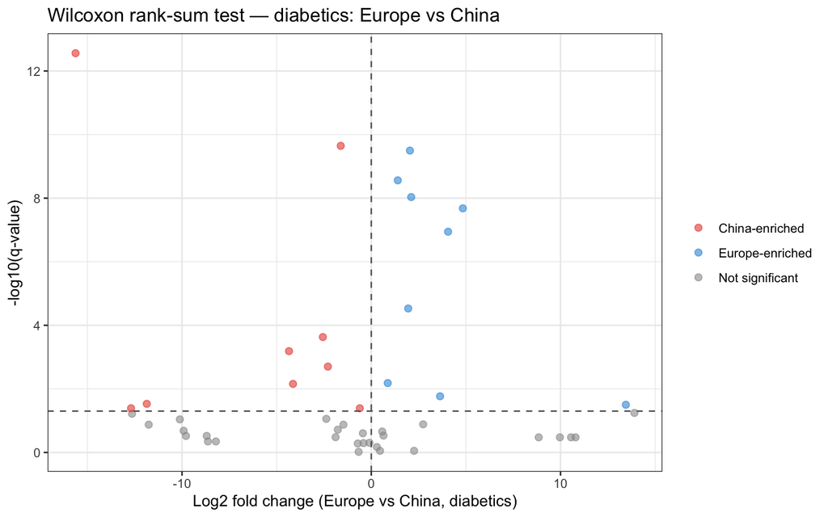

```r
# Volcano plot
wilcox_we %>%
  mutate(
    neg_log10_q = -log10(q_value),
    direction   = case_when(
      q_value < 0.05 & log2_fc > 0 ~ "Europe-enriched",
      q_value < 0.05 & log2_fc < 0 ~ "China-enriched",
      TRUE ~ "Not significant"
    )
  ) %>%
  ggplot(aes(x = log2_fc, y = neg_log10_q, color = direction)) +
    geom_point(alpha = 0.6, size = 2) +
    scale_color_manual(values = c(
      "Europe-enriched" = "#3498DB",
      "China-enriched"  = "#E74C3C",
      "Not significant" = "grey60"
    )) +
    geom_hline(yintercept = -log10(0.05), linetype = "dashed", color = "grey40") +
    geom_vline(xintercept = 0,            linetype = "dashed", color = "grey40") +
    labs(x = "Log2 fold change (Europe vs China, diabetics)",
         y = "-log10(q-value)", color = NULL,
         title = "Wilcoxon rank-sum test — diabetics: Europe vs China") +
    theme_bw()
```

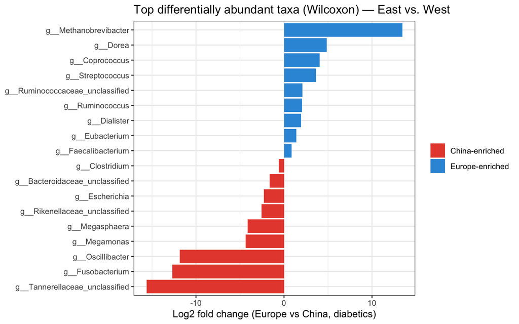

```r
# Top-taxa bar chart
bind_rows(
  wilcox_we %>% filter(q_value < 0.05) %>% arrange(-log2_fc) %>% head(10),
  wilcox_we %>% filter(q_value < 0.05) %>% arrange(log2_fc)  %>% head(10)
) %>%
  distinct() %>%
  mutate(direction = ifelse(log2_fc > 0, "Europe-enriched", "China-enriched")) %>%
  ggplot(aes(x = reorder(Genus, log2_fc), y = log2_fc, fill = direction)) +
    geom_col() +
    coord_flip() +
    scale_fill_manual(values = c(
      "Europe-enriched" = "#3498DB",
      "China-enriched"  = "#E74C3C"
    )) +
    labs(x = NULL,
         y = "Log2 fold change (Europe vs China, diabetics)",
         fill = NULL,
         title = "Top differentially abundant taxa (Wilcoxon) — East vs. West") +
    theme_bw()
```

## Compositional Analysis — CLR Linear Model (Constrained Ordination — RDA)

```r
clr_we <- run_clr_lm(
  ps_clr      = we_t$clr,
  formula_str = "clr ~ country + age + depth",
  term_filter = "countryEurope"
)

we_china_enriched <- clr_we %>%
  select(taxon, Genus, estimate, std.error, statistic, p.value, q_value) %>%
  arrange(estimate) %>%
  head(10)

we_europe_enriched <- clr_we %>%
  select(taxon, Genus, estimate, std.error, statistic, p.value, q_value) %>%
  arrange(-estimate) %>%
  head(10)

we_china_enriched
```

```
## # A tibble: 10 × 7
##    taxon  Genus                   estimate std.error statistic  p.value  q_value
##    <chr>  <chr>                      <dbl>     <dbl>     <dbl>    <dbl>    <dbl>
##  1 375288 g__Tannerellaceae_uncl…   -13.6      1.42      -9.62 1.56e-16 9.05e-15
##  2 561    g__Escherichia             -9.46     1.70      -5.57 1.61e- 7 6.23e- 7
##  3 239759 g__Rikenellaceae_uncla…    -6.37     1.99      -3.21 1.73e- 3 4.55e- 3
##  4 816    g__Bacteroidaceae_uncl…    -4.69     1.22      -3.83 2.04e- 4 5.92e- 4
##  5 158846 g__Megamonas               -3.99     1.53      -2.61 1.02e- 2 2.36e- 2
##  6 906    g__Megasphaera             -3.97     1.33      -2.99 3.43e- 3 8.29e- 3
##  7 1578   g__Lactobacillus           -3.16     1.35      -2.33 2.15e- 2 4.79e- 2
##  8 1485   g__Clostridium             -3.07     1.84      -1.67 9.82e- 2 1.54e- 1
##  9 283168 g__Bacteroidales_uncla…    -2.74     0.912     -3.01 3.22e- 3 8.12e- 3
## 10 570    g__Klebsiella              -2.11     1.09      -1.93 5.59e- 2 1.01e- 1
```

```r
we_europe_enriched
```

```
## # A tibble: 10 × 7
##    taxon  Genus                     estimate std.error statistic p.value q_value
##    <chr>  <chr>                        <dbl>     <dbl>     <dbl>   <dbl>   <dbl>
##  1 1263   g__Ruminococcus               9.58     1.81       5.28 5.90e-7 2.14e-6
##  2 292632 g__Ruminococcaceae_uncla…     9.00     1.86       4.84 4.02e-6 1.29e-5
##  3 1730   g__Eubacterium                8.91     1.57       5.67 1.01e-7 5.59e-7
##  4 189330 g__Dorea                      8.02     1.54       5.20 8.30e-7 2.83e-6
##  5 33042  g__Coprococcus                7.41     1.61       4.59 1.11e-5 3.38e-5
##  6 39948  g__Dialister                  6.13     1.71       3.58 5.05e-4 1.39e-3
##  7 216851 g__Faecalibacterium           4.15     1.88       2.21 2.92e-2 6.04e-2
##  8 841    g__Roseburia                  3.34     1.98       1.69 9.46e-2 1.52e-1
##  9 1301   g__Streptococcus              2.98     1.54       1.93 5.60e-2 1.01e-1
## 10 2172   g__Methanobrevibacter         1.81     0.856      2.11 3.69e-2 7.38e-2
```

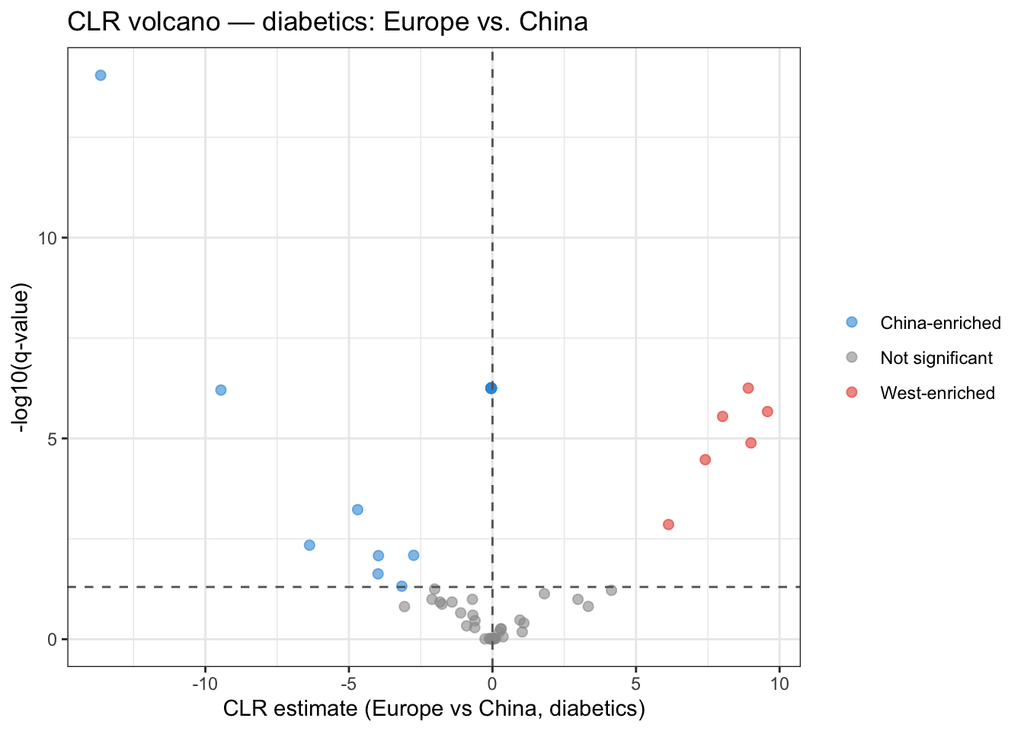

```r
plot_volcano(clr_we,
             x_label   = "CLR estimate (Europe vs China, diabetics)",
             title     = "CLR volcano — diabetics: Europe vs. China",
             pos_label = "West-enriched",
             neg_label = "China-enriched")
```

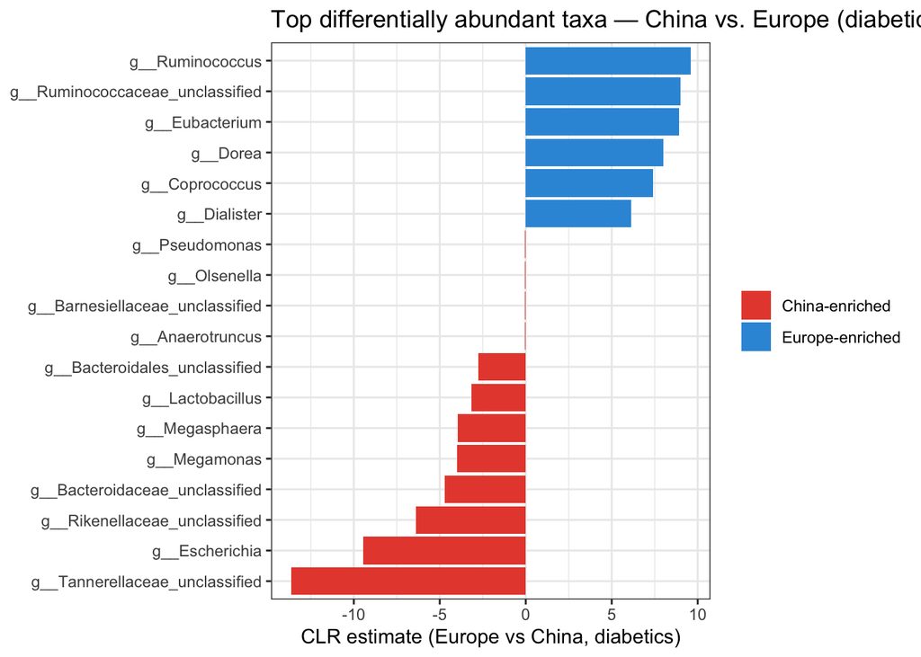

```r
plot_top_taxa(clr_we,
              x_label   = "CLR estimate (Europe vs China, diabetics)",
              title     = "Top differentially abundant taxa — China vs. Europe (diabetics)",
              pos_label = "Europe-enriched",
              neg_label = "China-enriched",
              pos_color = "#3498DB",
              neg_color = "#E74C3C")
```

### Wilcoxon vs CLR Comparison

```r
# Significant taxa summary
tibble(
  method        = c("Wilcoxon", "CLR"),
  n_significant = c(
    sum(wilcox_we$q_value < 0.05, na.rm = TRUE),
    sum(clr_we$q_value    < 0.05, na.rm = TRUE)
  )
)
```

```
## # A tibble: 2 × 2
##   method   n_significant
##   <chr>            <int>
## 1 Wilcoxon            18
## 2 CLR                 26
```

```r
# Consensus taxa significant in both methods
wilcox_we %>%
  select(taxon, Genus, wilcox_log2fc = log2_fc, wilcox_q = q_value) %>%
  inner_join(
    clr_we %>% select(taxon, clr_estimate = estimate, clr_q = q_value),
    by = "taxon"
  ) %>%
  filter(wilcox_q < 0.05, clr_q < 0.05) %>%
  mutate(direction_agreement = sign(wilcox_log2fc) == sign(clr_estimate)) %>%
  arrange(wilcox_q)
```

```
## # A tibble: 12 × 7
##    taxon  Genus wilcox_log2fc wilcox_q clr_estimate    clr_q direction_agreement
##    <chr>  <chr>         <dbl>    <dbl>        <dbl>    <dbl> <lgl>
##  1 375288 g__T…        -15.6  2.76e-13       -13.6  9.05e-15 TRUE
##  2 816    g__B…         -1.61 2.26e-10        -4.69 5.92e- 4 TRUE
##  3 1263   g__R…          2.04 3.19e-10         9.58 2.14e- 6 TRUE
##  4 1730   g__E…          1.40 2.75e- 9         8.91 5.59e- 7 TRUE
##  5 292632 g__R…          2.11 9.24e- 9         9.00 1.29e- 5 TRUE
##  6 189330 g__D…          4.84 2.09e- 8         8.02 2.83e- 6 TRUE
##  7 33042  g__C…          4.06 1.14e- 7         7.41 3.38e- 5 TRUE
##  8 39948  g__D…          1.95 2.96e- 5         6.13 1.39e- 3 TRUE
##  9 239759 g__R…         -2.56 2.34e- 4        -6.37 4.55e- 3 TRUE
## 10 158846 g__M…         -4.35 6.50e- 4        -3.99 2.36e- 2 TRUE
## 11 561    g__E…         -2.29 1.99e- 3        -9.46 6.23e- 7 TRUE
## 12 906    g__M…         -4.14 6.96e- 3        -3.97 8.29e- 3 TRUE
```

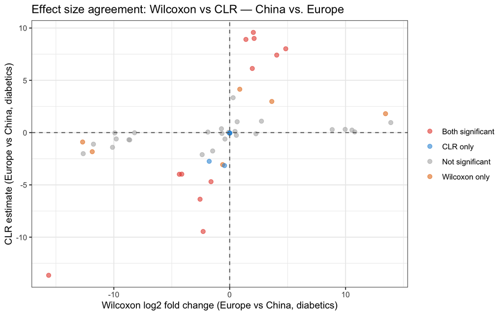

```r
# Cross-method effect size scatter
plot_wilcox_clr_comparison(
  wilcox_res     = wilcox_we,
  clr_res        = clr_we,
  wilcox_x_label = "Wilcoxon log2 fold change (Europe vs China, diabetics)",
  clr_y_label    = "CLR estimate (Europe vs China, diabetics)",
  title          = "Effect size agreement: Wilcoxon vs CLR — China vs. Europe"
)
```

### PCA of CLR Profiles

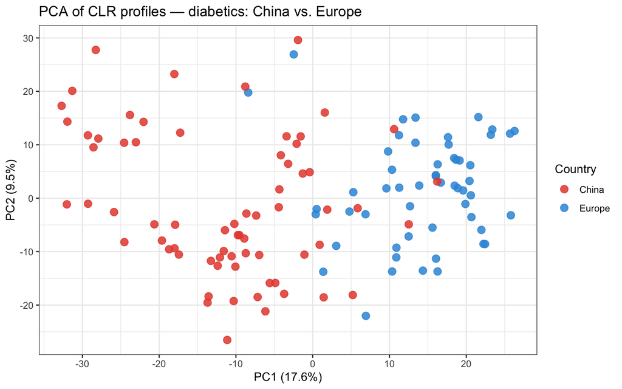

```r
otu_clr_we  <- as(otu_table(we_t$clr), "matrix") %>% t()
meta_clr_we <- as(sample_data(we_t$clr), "matrix") %>% as.data.frame()

pca_we  <- prcomp(otu_clr_we, center = TRUE, scale. = FALSE)
pca_var <- round(100 * pca_we$sdev^2 / sum(pca_we$sdev^2), 1)

as.data.frame(pca_we$x[, 1:2]) %>%
  rownames_to_column("sample_id") %>%
  left_join(meta_clr_we %>% rownames_to_column("sample_id"), by = "sample_id") %>%
  ggplot(aes(x = PC1, y = PC2, color = Country)) +
    geom_point(size = 3, alpha = 0.85) +
    scale_color_manual(values = c("China" = "#E74C3C", "Europe" = "#3498DB")) +
    labs(x = paste0("PC1 (", pca_var[1], "%)"),
         y = paste0("PC2 (", pca_var[2], "%)"),
         title = "PCA of CLR profiles — diabetics: China vs. Europe") +
    theme_bw()
```

### Constrained Ordination — RDA

```r
rda_we_out <- run_rda(
  ps_clr      = we_t$clr,
  formula_str = "Country + as.numeric(Host.age) + as.numeric(Nr..reads.sequenced)",
  covariates  = c("Country", "Host.age", "Nr..reads.sequenced")
)
```

```
## Samples removed due to NAs: 0
## Samples retained: 122
```

```r
anova(rda_we_out$rda, permutations = 999)
```

```
## Permutation test for rda under reduced model
## Permutation: free
## Number of permutations: 999
##
## Model: rda(formula = clr_clean ~ Country + as.numeric(Host.age) + as.numeric(Nr..reads.sequenced), data = meta_clean)
##           Df Variance      F Pr(>F)
## Model      3   201.76 6.2018  0.001 ***
## Residual 118  1279.63
## ---
## Signif. codes:  0 '***' 0.001 '**' 0.01 '*' 0.05 '.' 0.1 ' ' 1
```

```r
anova(rda_we_out$rda, by = "term", permutations = 999)
```

```
## Permutation test for rda under reduced model
## Terms added sequentially (first to last)
## Permutation: free
## Number of permutations: 999
##
## Model: rda(formula = clr_clean ~ Country + as.numeric(Host.age) + as.numeric(Nr..reads.sequenced), data = meta_clean)
##                                  Df Variance       F Pr(>F)
## Country                           1   176.57 16.2823  0.001 ***
## as.numeric(Host.age)              1    13.43  1.2383  0.202
## as.numeric(Nr..reads.sequenced)   1    11.77  1.0849  0.329
## Residual                        118  1279.63
## ---
## Signif. codes:  0 '***' 0.001 '**' 0.01 '*' 0.05 '.' 0.1 ' ' 1
```

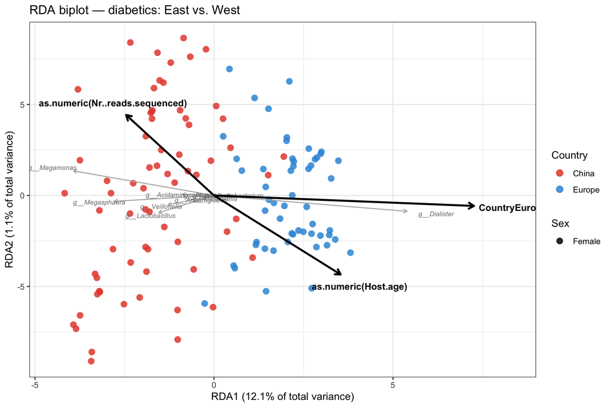

```r
plot_rda_biplot(
  rda_obj      = rda_we_out$rda,
  meta_df      = rda_we_out$meta,
  color_var    = "Country",
  shape_var    = "Sex",
  color_values = c("China" = "#E74C3C", "Europe" = "#3498DB"),
  shape_values = c("Female" = 16, "Male" = 17),
  title        = "RDA biplot — diabetics: East vs. West"
)
```

### Compare RDA and CLR

[figure not shown]

```r
rda1_scores_we <- scores(rda_we_out$rda, display = "sites")[, "RDA1"]
rda1_sign_we <- ifelse(
  mean(rda1_scores_we[rda_we_out$meta$Country == "Europe"],  na.rm = TRUE) >=
  mean(rda1_scores_we[rda_we_out$meta$Country == "China"], na.rm = TRUE),
  1, -1
)

comp_we <- compare_rda_clr(
  rda_obj  = rda_we_out$rda,
  clr_res  = clr_we,
  tax_df   = as(tax_table(we_t$clr), "matrix") %>% as.data.frame(),
  rda1_sign = rda1_sign_we
)

plot_rda_clr_comparison(
  comp_we,
  x_label = "CLR estimate (diabetic vs healthy)",
  y_label = "RDA1 loading (positive = diabetic side)",
  title   = "RDA loadings vs CLR estimates — global"
)
```

```r
comp_we %>%
  arrange((abs(clr_q))) %>%
  select(taxon, Phylum.x, Genus.x, rda1_loading, clr_estimate, clr_q, direction_agreement) %>%
  head(30)
```

```
## # A tibble: 30 × 7
##    taxon Phylum.x Genus.x rda1_loading clr_estimate    clr_q direction_agreement
##    <chr> <chr>    <chr>          <dbl>        <dbl>    <dbl> <lgl>
##  1 3752… p__Bact… g__Tan…      -3.48       -13.6    9.05e-15 TRUE
##  2 1730  p__Baci… g__Eub…       1.97         8.91   5.59e- 7 TRUE
##  3 46255 p__Baci… g__Wei…      -0.0109      -0.0450 5.59e- 7 TRUE
##  4 9462… p__Baci… g__Fla…      -0.0109      -0.0450 5.59e- 7 TRUE
##  5 2441… p__Baci… g__Ana…      -0.0109      -0.0450 5.59e- 7 TRUE
##  6 61170 p__Baci… g__Hol…      -0.0109      -0.0450 5.59e- 7 TRUE
##  7 1339… p__Acti… g__Ols…      -0.0109      -0.0450 5.59e- 7 TRUE
##  8 5773… p__Pseu… g__Par…      -0.0109      -0.0450 5.59e- 7 TRUE
##  9 846   p__Pseu… g__Oxa…      -0.0109      -0.0450 5.59e- 7 TRUE
## 10 581   p__Pseu… g__Mor…      -0.0109      -0.0450 5.59e- 7 TRUE
## # ℹ 20 more rows
```